# Gotta catch ’em all

**LIBRARIES**

```r
library(dplyr)
```

```r
library(ggplot2)
library(gridExtra)
library(hrbrthemes)
library(viridis)
```

**PATH for the Excel file**

```r
Pokemon<-read.csv("C:\\Users\\Adrian\\Desktop\\DAB_Datasets\\Pokemon.csv")
```

**Dataset**

```r
glimpse(Pokemon)
```

```
## Rows: 75
## Columns: 27
## $ name                    <chr> "Pidgey1", "Pidgey2", "Pidgey3", "Pidgey4",...
## $ species                 <chr> "Pidgey", "Pidgey", "Pidgey", "Pidgey", "Pi...
## $ cp                      <int> 384, 366, 353, 338, 242, 129, 10, 25, 24, 1...
## $ hp                      <int> 56, 54, 55, 51, 45, 35, 10, 14, 13, 35, 31,...
## $ weight                  <dbl> 2.31, 1.67, 1.94, 1.73, 1.44, 2.07, 0.92, 2...
## $ height                  <dbl> 0.34, 0.29, 0.30, 0.31, 0.27, 0.35, 0.25, 0...
## $ power_up_stardust       <int> 2500, 2500, 3000, 3000, 1900, 800, 200, 200...
## $ power_up_candy          <int> 2, 2, 3, 3, 2, 1, 1, 1, 1, 1, 1, 3, 1, 1, 1...
## $ attack_weak             <chr> "Tackle", "Quick Attack", "Quick Attack", "...
## $ attack_weak_type        <chr> "Normal", "Normal", "Normal", "Normal", "No...
## $ attack_weak_value       <int> 12, 10, 10, 12, 10, 10, 12, 12, 10, 12, 12,...
## $ attack_strong           <chr> "Aerial Ace", "Twister", "Aerial Ace", "Air...
## $ attack_strong_type      <chr> "Flying", "Dragon", "Flying", "Flying", "Fl...
## $ attack_strong_value     <int> 30, 25, 30, 30, 30, 30, 30, 25, 25, 25, 30,...
## $ cp_new                  <int> 694, 669, 659, 640, 457, 243, 15, 47, 47, 3...
## $ hp_new                  <int> 84, 81, 83, 79, 69, 52, 13, 21, 21, 54, 47,...
## $ weight_new              <dbl> 2.60, 1.93, 3.51, 30.00, 1.42, 30.00, 30.00...
## $ height_new              <dbl> 1.24, 1.05, 1.11, 1.12, 0.98, 1.27, 0.90, 1...
## $ power_up_stardust_new   <int> 2500, 2500, 3000, 3000, 1900, 800, 200, 200...
## $ power_up_candy_new      <int> 2, 2, 3, 3, 2, 1, 1, 1, 1, 1, 1, 3, 1, 1, 1...
## $ attack_weak_new         <chr> "Steel Wing", "Wing Attack", "Wing Attack",...
## $ attack_weak_type_new    <chr> "Steel", "Flying", "Flying", "Steel", "Flyi...
## $ attack_weak_value_new   <int> 15, 9, 9, 15, 9, 9, 9, 15, 9, 15, 9, 15, 9,...
## $ attack_strong_new       <chr> "Air Cutter", "Air Cutter", "Air Cutter", "...
## $ attack_strong_type_new  <chr> "Flying", "Flying", "Flying", "Flying", "Dr...
## $ attack_strong_value_new <int> 30, 30, 30, 30, 25, 30, 30, 30, 25, 30, 30,...
## $ notes                   <chr> "", "", "", "", "", "", "", "", "", "", "",...
```

The dataset consists of 75 observations and 27 variables.It gives us information about the 4 different Pokemon species.

The variables are :-

**Calculate the diference in heights pre and post evolution and save this as a new variable. Calculate the percentage of Pokémon that grew during evolution. Also visualize the distribution of change in height by species and provide a discussion of how change in height varies across species.**

To calculate the percentage of height that the Pokemon grew, we need to calculate using the below formula  
difference in height= new height(Post evolution) - original height(Pre evolution)  
percentage of growth = (difference in height/original height)*100

A new column growth_Percent is created with the calculations mentioned above.

```r
percent<-function(diff,original){
    percent_value=((diff/original)*100)
    #return(paste(percent_value,"%"))
    return(percent_value)
}

q1<-Pokemon %>%
    mutate(diff_in_height=height_new-height,
           growth_Percent=percent(diff_in_height,height))
```

Below is the dataset with new added column growth_percent

```r
q1
```

| name | species | cp | hp | weight | height | power_up_stardust | power_up_candy | attack_weak | attack_weak_type | attack_weak_value | attack_strong | attack_strong_type | attack_strong_value | cp_new | hp_new | weight_new | height_new | power_up_stardust_new | power_up_candy_new | attack_weak_new | attack_weak_type_new | attack_weak_value_new | attack_strong_new | attack_strong_type_new | attack_strong_value_new | notes | diff_in_height | growth_Percent |
| --- | --- | --- | --- | --- | --- | --- | --- | --- | --- | --- | --- | --- | --- | --- | --- | --- | --- | --- | --- | --- | --- | --- | --- | --- | --- | --- | --- | --- |
| Pidgey1 | Pidgey | 384 | 56 | 2.31 | 0.34 | 2500 | 2 | Tackle | Normal | 12 | Aerial Ace | Flying | 30 | 694 | 84 | 2.60 | 1.24 | 2500 | 2 | Steel Wing | Steel | 15 | Air Cutter | Flying | 30 |  | 0.90 | 264.70588 |
| Pidgey2 | Pidgey | 366 | 54 | 1.67 | 0.29 | 2500 | 2 | Quick Attack | Normal | 10 | Twister | Dragon | 25 | 669 | 81 | 1.93 | 1.05 | 2500 | 2 | Wing Attack | Flying | 9 | Air Cutter | Flying | 30 |  | 0.76 | 262.06897 |
| Pidgey3 | Pidgey | 353 | 55 | 1.94 | 0.30 | 3000 | 3 | Quick Attack | Normal | 10 | Aerial Ace | Flying | 30 | 659 | 83 | 3.51 | 1.11 | 3000 | 3 | Wing Attack | Flying | 9 | Air Cutter | Flying | 30 |  | 0.81 | 270.00000 |
| Pidgey4 | Pidgey | 338 | 51 | 1.73 | 0.31 | 3000 | 3 | Tackle | Normal | 12 | Air Cutter | Flying | 30 | 640 | 79 | 30.00 | 1.12 | 3000 | 3 | Steel Wing | Steel | 15 | Air Cutter | Flying | 30 |  | 0.81 | 261.29032 |
| Pidgey5 | Pidgey | 242 | 45 | 1.44 | 0.27 | 1900 | 2 | Quick Attack | Normal | 10 | Air Cutter | Flying | 30 | 457 | 69 | 1.42 | 0.98 | 1900 | 2 | Wing Attack | Flying | 9 | Twister | Dragon | 25 |  | 0.71 | 262.96296 |
| Pidgey6 | Pidgey | 129 | 35 | 2.07 | 0.35 | 800 | 1 | Quick Attack | Normal | 10 | Air Cutter | Flying | 30 | 243 | 52 | 30.00 | 1.27 | 800 | 1 | Wing Attack | Flying | 9 | Aerial Ace | Flying | 30 |  | 0.92 | 262.85714 |
| Pidgey7 | Pidgey | 10 | 10 | 0.92 | 0.25 | 200 | 1 | Tackle | Normal | 12 | Air Cutter | Flying | 30 | 15 | 13 | 30.00 | 0.90 | 200 | 1 | Wing Attack | Flying | 9 | Air Cutter | Flying | 30 |  | 0.65 | 260.00000 |
| Pidgey8 | Pidgey | 25 | 14 | 2.72 | 0.37 | 200 | 1 | Tackle | Normal | 12 | Twister | Dragon | 25 | 47 | 21 | 2.63 | 1.35 | 200 | 1 | Steel Wing | Steel | 15 | Air Cutter | Flying | 30 |  | 0.98 | 264.86486 |
| Pidgey9 | Pidgey | 24 | 13 | 2.07 | 0.32 | 200 | 1 | Quick Attack | Normal | 10 | Twister | Dragon | 25 | 47 | 21 | 3.27 | 1.16 | 200 | 1 | Wing Attack | Flying | 9 | Twister | Dragon | 25 |  | 0.84 | 262.50000 |
| Pidgey10 | Pidgey | 161 | 35 | 1.45 | 0.31 | 1000 | 1 | Tackle | Normal | 12 | Twister | Dragon | 25 | 305 | 54 | 30.00 | 1.14 | 1000 | 1 | Steel Wing | Steel | 15 | Aerial Ace | Flying | 30 |  | 0.83 | 267.74194 |

[output cut: 65 more lines]

Below is the evolution of the species based on the height.

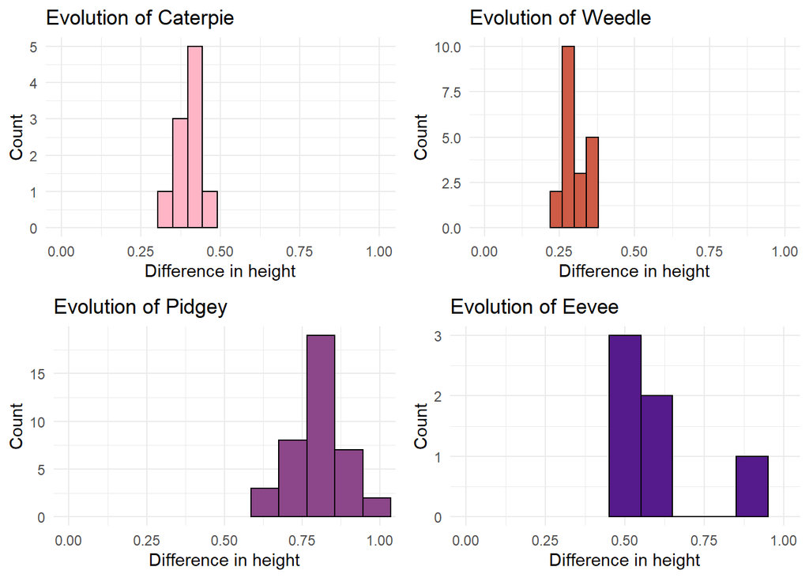

```r
p1<-ggplot(q1 %>% filter(species=="Caterpie"),
       aes(x = diff_in_height)) +
  geom_histogram(bins = 4,fill="pink1", color="black")+
  coord_cartesian(xlim = c(0,1))+
  ggtitle("Evolution of Caterpie")+
  labs(y = "Count",
       x = "Difference in height")+
  theme_minimal()

p2<-ggplot(q1 %>% filter(species=="Weedle"),
           aes(x = diff_in_height)) +
  geom_histogram(bins=5,fill="coral3", color="black")+
  coord_cartesian(xlim = c(0,1))+
  ggtitle("Evolution of Weedle")+
  labs(y = "Count",
       x = "Difference in height")+
  theme_minimal()



p3<-ggplot(q1 %>% filter(species=="Pidgey"),
       aes(x = diff_in_height)) +
  geom_histogram(bins=5,fill="orchid4", color="black")+
  coord_cartesian(xlim = c(0,1))+
  ggtitle("Evolution of Pidgey")+
  labs(y = "Count",
       x = "Difference in height")+
    theme_minimal()

p4<-ggplot(q1 %>% filter(species=="Eevee"),
       aes(x = diff_in_height)) +
  geom_histogram(bins=4,fill="purple4", color="black",binwidth = 0.1)+
  coord_cartesian(xlim = c(0,1))+
  ggtitle("Evolution of Eevee")+
  labs(y = "Count",
       x = "Difference in height")+
    theme_minimal()


grid.arrange(p1,p2,p3,p4)
```

**Observation** 1)“Pidgey” show symmetric and unimodal distribution.  
2)“Caterpie” shows unimodal distribution.  
2)“Weedle” shows bimodal distribution .  
3) “Eevee” shows right skewness and unimodal distribution.  
* There is insufficient data in “Eevee” to mark the 1 value as an outlier

**Recreate the following plot**

```r
Ex2<-Pokemon %>%
     filter(species %in% c("Caterpie","Eevee","Pidgey"))%>%
     group_by(species) %>%
    summarise(attack_weak)
```

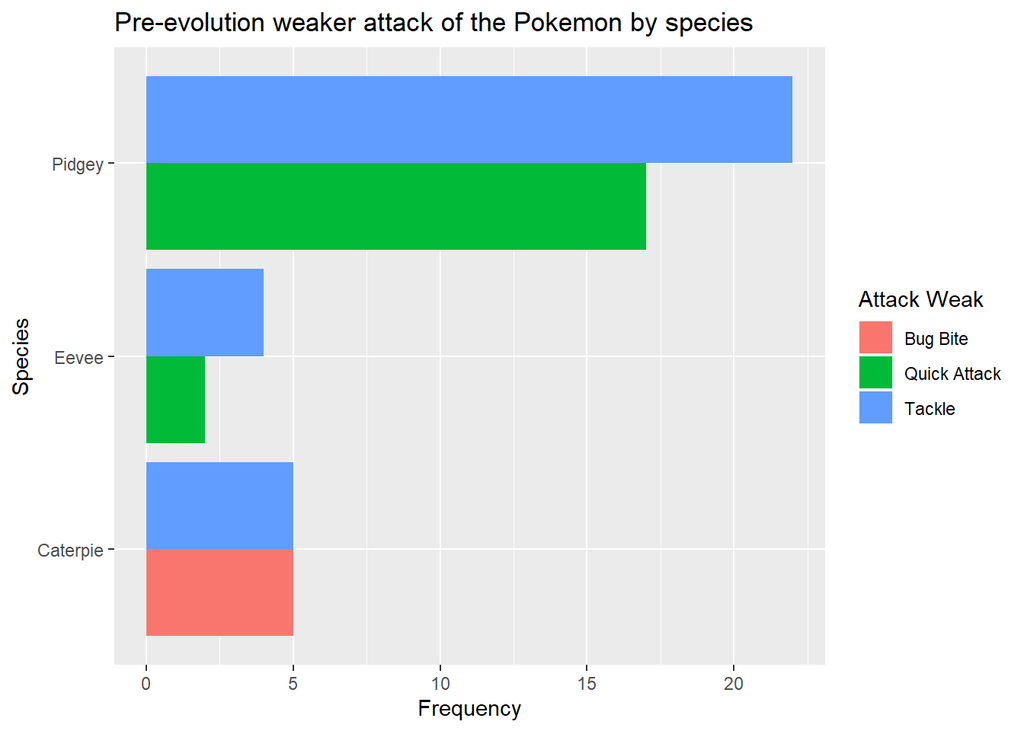

```r
ggplot(Ex2, mapping=aes(y=Ex2$species,fill=attack_weak))+
  geom_bar(stat="count",
           position="dodge")+
  labs(x="Frequency", y="Species",
       title = "Pre-evolution weaker attack of the Pokemon by species")+
  guides(fill=guide_legend(title="Attack Weak"))
```

**Description**  
The plot depicts the Pre-evolution attacks of the Pokemon. In the above mentioned plot only 3 species are considered namely - “Pidgey”,“Eevee”,“Caterpie”.

**Observation**  
The weaker attacks for “Pidgey” and “Eevee” is Tackle,Quick attack whereas for Caterpie is Tackle and Bug bite.

**Pick two categorical variables and make a bar plot that depicts the relationship between them. These can be variables from the original data or ones that you create based on the given data.**

The below plot depicts the relationship between 2 categorical variables species and attack strong type.

```r
Ex3 <- Pokemon %>%
  group_by(species) %>%
  summarise(attack_strong_type)
```

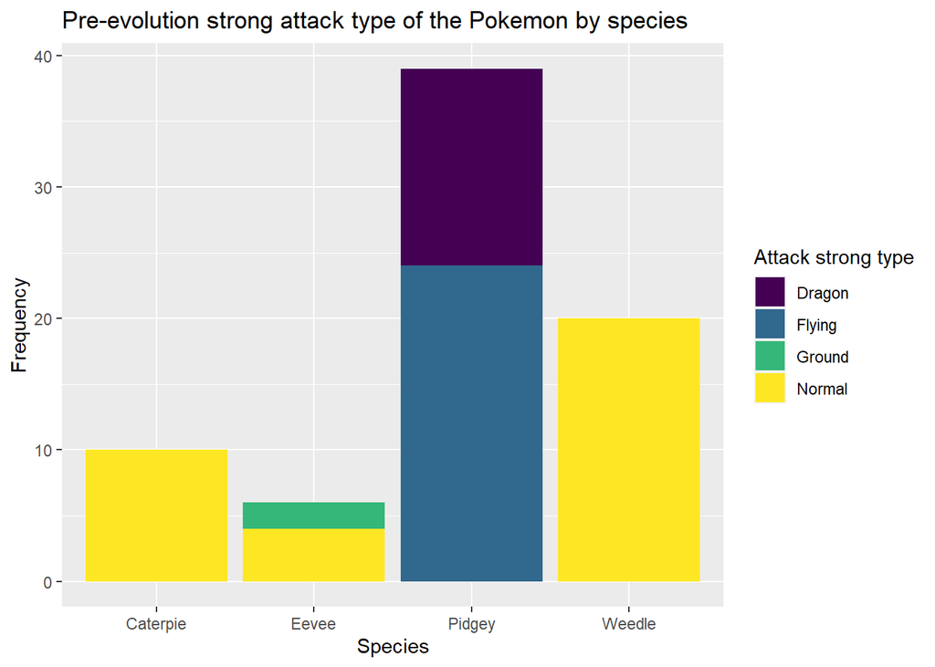

```r
ggplot(data=Ex3, mapping=aes(x=species,fill=attack_strong_type))+
  geom_bar(stat="count")+
  scale_fill_viridis(discrete=TRUE, name="") +
  labs(x="Species", y="Frequency",
       title = "Pre-evolution strong attack type of the Pokemon by species")+
  guides(fill=guide_legend(title="Attack strong type"))
```

**Description**  
The attack strong type is the stronger attack of the Pokemon before evolution. We have plotted the species and their corresponding stronger attack type pre evolution.

**Observation**  
1)From the above plot we can conclude that “Caterpie” and “Weedle” have Normal as the stronger attack types.  
2)In case of “Pidgey” the stronger attack types are Flying and Dragon.  
3)Whereas in case of Eevee the stronger attack types are Normal and Ground.

*Pick a numerical and a categorical variable, and construct side-by-side box plots depicting the relationship between them.*

```r
   Ex4<-Pokemon %>%
      group_by(species) %>%
      summarise(cp)
```

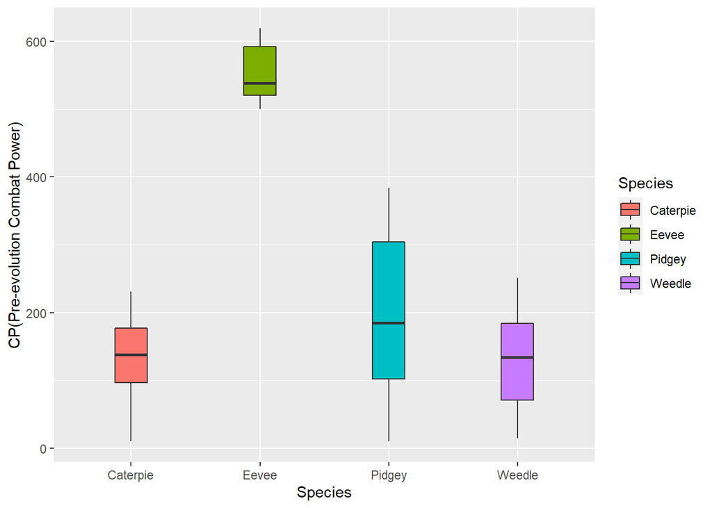

```r
ggplot(data=Ex4, aes(x=species,y=cp,fill=species))+
  geom_boxplot(width=0.25)+
  labs(x="Species", y="CP(Pre-evolution Combat Power)")+
  guides(fill=guide_legend(title="Species"))
```

**Description**  
The above mentioned box plot represents the different species along with the pre evolution combat power.

Using the above box plot we can draw conclusions.  
1)The line in the middle denotes the median value of that specie(Q2).  
2)The line below the box is the minimum value.  
3)The line above the box is the maximum value.  
4)The start of the box shows the Q1(25 Percentile).  
5)The end of the box shows the Q3(75 Percentile).  
6)The difference betweeen Q1 and Q3 is the box or the Interquartile range(IQR).

**Learn something new: violin plots! Read about them at http://ggplot2.tidyverse.org/reference/geom_violin.html, and convert your side-by-side box plots from the previous task to violin plots. What do the violin plots reveal that box plots do not? What features are apparent in the box plots but not in the violin plots?**

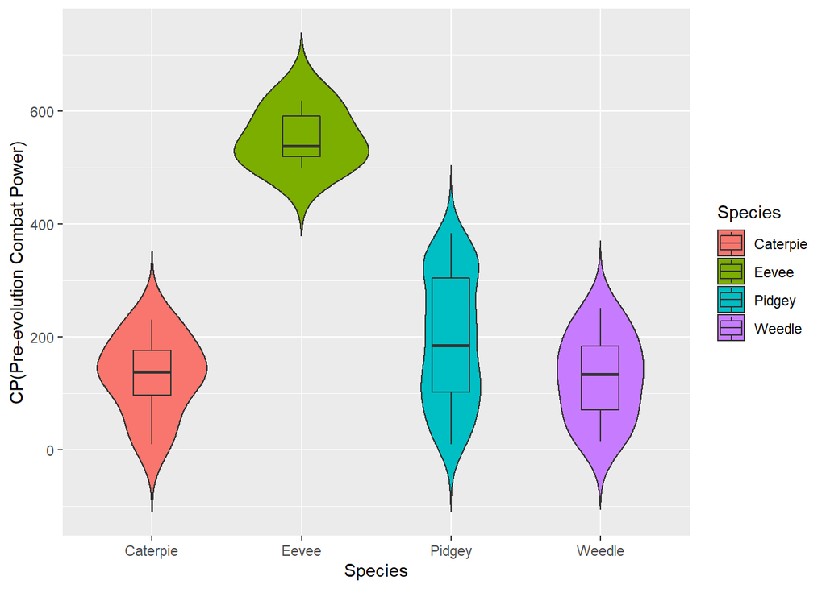

```r
library(hrbrthemes)
library(viridis)
extrafont::loadfonts(device="win")

ggplot(data=Ex4, aes(x=species,y=cp,fill=species))+
  geom_violin(trim = FALSE,bw =40)+
  geom_boxplot(width=0.25)+
  #theme_ipsum() +
  #scale_fill_viridis(discrete = TRUE) +

  labs(x="Species", y="CP(Pre-evolution Combat Power)")+
  guides(fill=guide_legend(title="Species"))
```

**Description** The above plot is a violin representation of the box plot. It denotes the pre-evolution combat power of every species.

**Observation** From the above Violin plot we can visualize the distribution of a numeric variable for one or several species. In the above case each violin represents a specie. The shape denotes the density of the spieces. It denotes how many data points in that range.It is like a mirror image of the density plot with a box plot inside .  
Using the plot we can conclude that more data points are present for “Caterpie” between the range 150-200. For “Eevee” the max data points are visible around the 500 mark. The larger the range the larger the violin.  
It can provide a more insights and provides more understanding of the distribution.

Key features-  
1)Full distribution of the data points.  
2)Density of the points at different values.

**What characteristics correspond to an evolved Pokémon with a high combat power? You do not need to come up with an exhaustive list, but you should walk us through your reasoning for answering this question and include all relevant summary statistics and visualizations.**

We are making use of the summarize() to find the mean of the combat power. Using the results we will utilize the top 2 largest mean values which will denote species of higher combat power.

```r
Pokemon %>%
  group_by(species) %>%
  summarise(Mean_cp=mean(cp)) %>%
  arrange(desc(Mean_cp))
```

| species | Mean_cp |
| --- | --- |
| Eevee | 553.0000 |
| Pidgey | 194.7179 |
| Caterpie | 131.7000 |
| Weedle | 127.9500 |

We can conclude hat “Eevee” and “Pidgey” have the highest combat power. Therefore we will consider the Hit power (HP) of these species to determine their characteristics.

First let us check the summary statistics for all species.

```r
#summary statistics
print(summary(Pokemon$hp))
```

```
##    Min. 1st Qu.  Median    Mean 3rd Qu.    Max.
##   10.00   30.50   43.00   40.69   50.00   74.00
```

```r
print(summary(Pokemon$hp_new))
```

```
##    Min. 1st Qu.  Median    Mean 3rd Qu.    Max.
##   10.00   43.50   54.00   56.39   68.50  165.00
```

```r
Pokemon %>%
  group_by(species) %>%
  summarise(max(hp),max(hp_new))
```

| species | max(hp) | max(hp_new) |
| --- | --- | --- |
| Caterpie | 62 | 68 |
| Eevee | 74 | 165 |
| Pidgey | 56 | 84 |
| Weedle | 56 | 62 |

From the summary statistics above we can determine the following  
1)The Minimum value has not decreased post evolution.  
2)The Maximum value has increased post evolution signalling more HP is required due to more power.  
3)The Mean,Median,1st quartile,3rd quartile has also increased  
All the above points signal that higher the CP, higher HP(Hit power is also higher)

Let us visualize to rectify the conclusions made through summary statistics

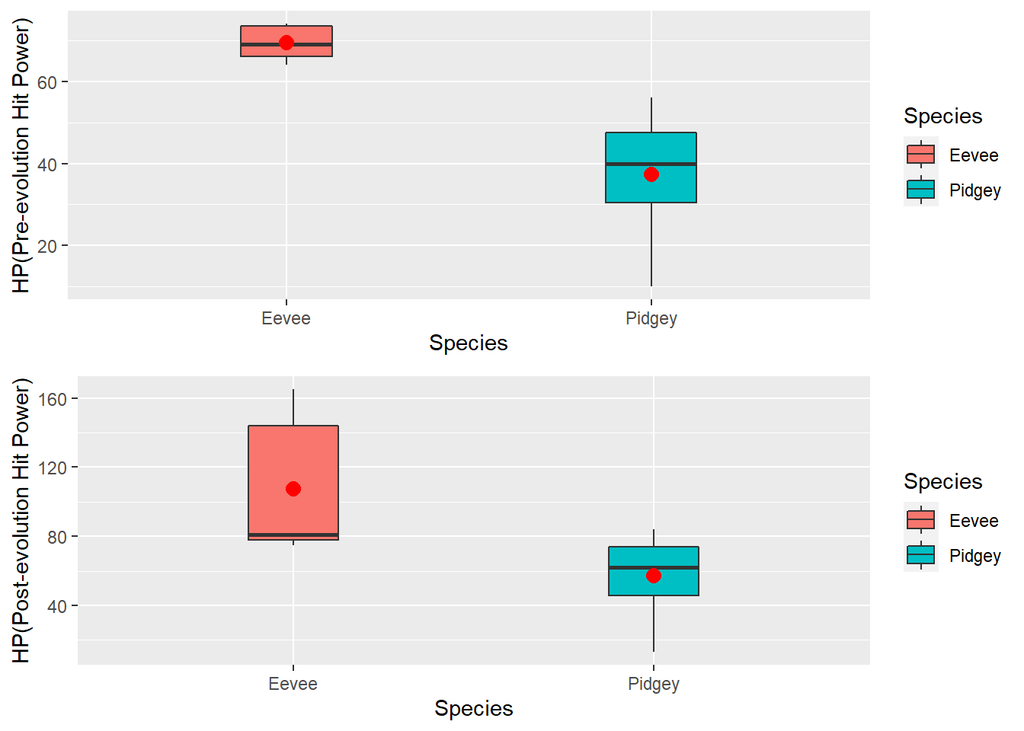

```r
Ex6a<-Pokemon %>%
      filter(species %in% c ("Eevee","Pidgey")) %>%
      summarise(species,hp,hp_new)

#Pre evolution
p6a<-ggplot(data=Ex6a , aes(x=species,y=hp,fill=species))+
      geom_boxplot(width=0.25)+
      stat_summary(fun.y=mean, geom="point", shape=20, size=5,
                   color="red",  fill="red") +
      labs(x="Species", y="HP(Pre-evolution Hit Power)")+
      guides(fill=guide_legend(title="Species"))
#Post evolution
p6b<-ggplot(data=Ex6a , aes(x=species,y=hp_new,fill=species))+
      geom_boxplot(width=0.25)+
      stat_summary(fun.y=mean, geom="point", shape=20, size=5,
                   color="red",  fill="red")+
      labs(x="Species", y="HP(Post-evolution Hit Power)")+
      guides(fill=guide_legend(title="Species"))
grid.arrange(p6a,p6b)
```

**Observation**  
The red dot denotes the mean.

```
1) For Pidgey -
           a)The mean value in Pre-evolution = 37 whereas  Post evolution = 59(approx) .
           b)The min value in Pre-evolution = 10 whereas  Post evolution = 13.
           c)The max value in Pre-evolution = 56 whereas  Post evolution = 84

 2) For Evee -
          a)The  mean value in Pre-evolution = 70 whereas  Post evolution =110 (approx).
          b)The min value in Pre-evolution = 64 whereas  Post evolution = 75.
          c)The max value in Pre-evolution = 74 whereas  Post evolution = 165.
```

Using the above conclusions and the box plot we can state that with higher combat power the characteristics of hit power has also increased.